# Genome-wide Allele Frequencies straight from the BAMs

# Parts done on a the cluster

Things in this section were all done on a cluster. The code in this section is not evaluated when rendering the notebook. The code, however, shows how the allele frequencies were calculated and then placed into `stored_results`.

## Preparing bamlists

Note that 000 must have been run before this to fill the `chinook_WGS_processed` directory.

First, make some directories:

```bash
mkdir -p intermediates/202
```

```bash
awk -F"," '$NF=="Fall" {print "chinook_WGS_processed/" $1 ".rmdup.bam"}' data/wgs-chinook-samples.csv > intermediates/202/fall.bamlist
awk -F"," '$NF=="Spring" {print "chinook_WGS_processed/" $1 ".rmdup.bam"}' data/wgs-chinook-samples.csv > intermediates/202/spring.bamlist
```

## Break genome up into a lot of separate jobs

Now, make a bunch of files holding genomic regions for an array in which the genome is broken down into roughly 1 Mb fragments, or collections of fewer than a 100 scaffolds.

```bash
module load bio/samtools

# get file of all scaffolds represented in the BAMs:
samtools view -H chinook_WGS_processed/DPCh_plate1_A01_S1.rmdup.bam | awk '/^@SQ/' | sed 's/:/ /g;' | \
   awk '{print $3, $NF}' > intermediates/202/chroms-and-lengths.txt

# now, break those regions into genomic coordinates in files
mkdir intermediates/202/region_files

# first make a flat list of them
awk '
  BEGIN {idx = -1}
  idx == -1 {start = 1;  rem = $2; idx = 0;}
  $NF > 1e6 { # anything longer than 1 Mb gets broken up

    if(just_inced_idx == 1) {
      idx--;
      just_inced_idx = 0;
    }
    rem = $NF;  # set the remaining length whenever you get into a new fragment

    start = 1;
    if(rem > 1e6) {
      while(rem > 0) {
        right = start + 1e06 - 1;
        if(right > $2) {
          right = $2;
        }
        rem = rem - 1e06
        printf("%d\t%s:%d-%d\n", ++idx, $1, start, right);
        start = right + 1
      }
    }
    tot=0;
    num=0
    next;
  }

  {  # otherwise, here we deal with any scaffolds less than 1e06
    just_inced_idx = 0
    tot+=$2;
    num++;
    printf("%d\t%s:%d-%d\n", idx, $1, 1, $2);
    if(tot > 1e06 || num >= 100) {
      tot = 0;
      num = 0;
      idx++;
      just_inced_idx = 1;
    }
  }
' intermediates/202/chroms-and-lengths.txt > intermediates/202/region-flat-file.tsv

# now, break those down into separate files
awk '
{
  if(fidx>0 && fidx<$1) {
    close(file);
  }
  fidx = $1

  file = sprintf("intermediates/202/region_files/%04d.txt", fidx);
  print $2 > file;
}' intermediates/202/region-flat-file.tsv
```

## Job array for estimating alle freqs in springs and falls

Make some directories to put results

```bash
mkdir -p intermediates/202/MAFS
mkdir -p intermediates/202/{slurm_out,slurm_err,stderr,stdout}
```

Run a job array.

```bash
# then launch that as an array of 2492 jobs
sbatch script/202-01-angsd-array.sh
# Submitted batch job 44737
```

That did not take too long, but check to see if there are any failures:

```bash
for i in intermediates/202/stderr/*stderr; do gotit=$(tail -n 1 $i | awk 'BEGIN {msg="No"} /ALL done/ {msg="Yes"} END {print msg}'); if [ $gotit = No ]; then echo $i; fi; done
```

Nope! Setting minMapQ=30 removed the couple of memory failures we had previously.

## Joining and filtering the allele freqs

Finally, put them all together into a single file for springers and a single file for falls:

```bash
mkdir intermediates/202/tmp-agged-mafs
cat intermediates/202/MAFS/fall.*.mafs.gz | zcat | awk 'NR==1 {print; next} /^chromo/ {next} {print}'  > intermediates/202/tmp-agged-mafs/fall-mafs-from-bam.mafs
cat intermediates/202/MAFS/spring.*.mafs.gz | zcat | awk 'NR==1 {print; next} /^chromo/ {next} {print}' > intermediates/202/tmp-agged-mafs/spring-mafs-from-bam.mafs
```

Now, read them into R and join them there

```r
library(tidyverse)

ff <- read_tsv("intermediates/202/tmp-agged-mafs/fall-mafs-from-bam.mafs")
sf <- read_tsv("intermediates/202/tmp-agged-mafs/spring-mafs-from-bam.mafs")

# now inner join them on chrom and pos
joined <- inner_join(ff, sf, by = c("chromo", "position"))

# check that there are none that have major/minor mixed up:
joined %>% filter(major.x != major.y)

# now arrange by abs_diff
abs_diffs_from_bams <- joined %>%
  mutate(abs_diff = abs(knownEM.x - knownEM.y)) %>%
  select(chromo, position, abs_diff)

# that has 13.6 million rows.  Let's filter it down to diffs > 0.25
# as we use for the plot in the paper.
abs_diffs_from_bams_gt0.25 <- abs_diffs_from_bams %>%
  filter(abs_diff > 0.25)

# that ends up being only 46K variants or so.

# save that in stored results
dir.create("stored_results/202")
write_rds(abs_diffs_from_bams_gt0.25, path = "stored_results/202/abs_diffs_from_bams_gt0.25.rds", compress = "xz")
```

Final thing we need to do is get the chromosome lengths from one of the bam files and put those into stored results.

```bash
module load bio/samtools

samtools view -H chinook_WGS_processed/DPCh_plate1_A01_S1.rmdup.bam | awk -F":" '/^@SQ/ {print $2, $3}' | awk 'BEGIN {printf("Chromosome\tchrom_length\n");} {printf("%s\t%s\n",$1, $3);}' | gzip -c > stored_results/202/chrom_lengths_from_bams.txt.gz
```

# Making the plot from the stored results

This part is done on a laptop, not the cluster, and will be evaluated when the RMarkdown document is rendered.

Get the chrom lengths and data

```r
library(tidyverse)
dir.create("outputs/202", recursive = TRUE, showWarnings = FALSE)

chrom_lengths <- read_tsv("stored_results/202/chrom_lengths_from_bams.txt.gz")
freq_diffs <- read_rds("stored_results/202/abs_diffs_from_bams_gt0.25.rds") %>%
  rename(Chromosome = chromo)
```

Source the functions we need:

```r
source("R/manhattan_plot_funcs.R")
```

Now, do it:

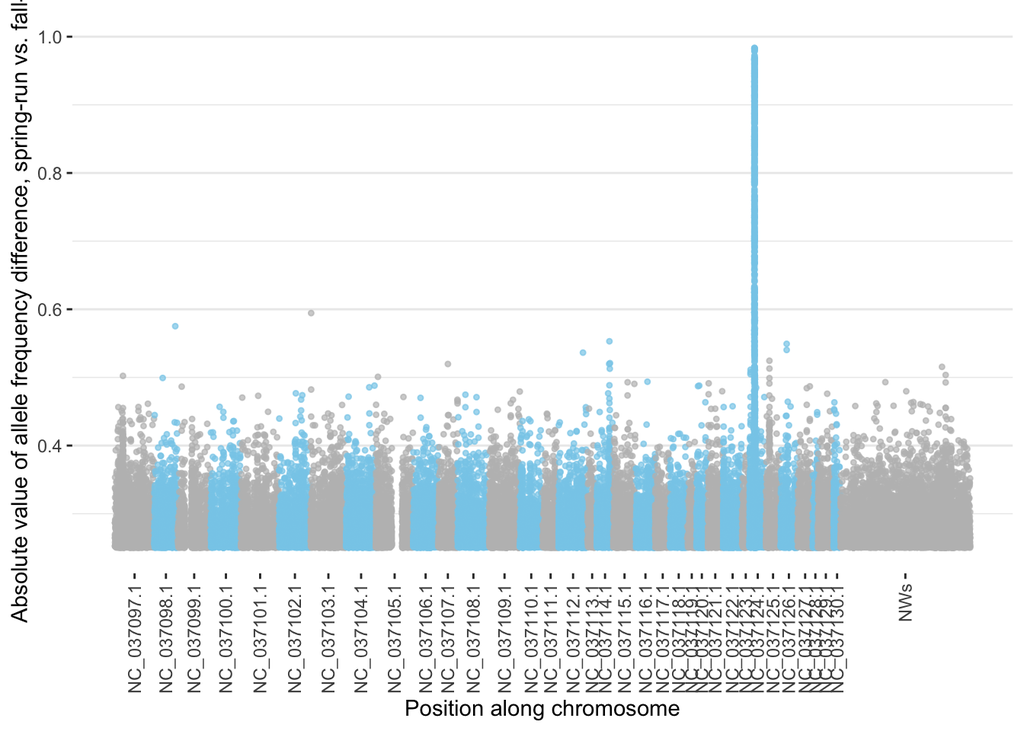

```r
sf_bammed <- my_mh_prep(freq_diffs, chrom_lengths)

mh_plot_from_bams <- plot_mh(sf_bammed$snps, sf_bammed$axisdf) +
  xlab("Position along chromosome") +
  ylab("Absolute value of allele frequency difference, spring-run vs. fall-run")

mh_plot_from_bams
```

Note that this is essentially identical to the same plot made using as input to ANGSD the genotype likelihoods in the VCF file computed by GATK, and then filling the “holes” (sections where GATK apparently failed) with allele frequencies estimated directly from the BAMs.

The only difference, interestingly, is the omission in the present plot of some sites that have an absolute difference closer to 1.00. Such sites do not occur in the current plot because ANGSD does discovery on each data set (fall and spring) separately. We tried forcing the same sites to be called in the two ANGSD runs using the -sites option. We received a warning that the -sites option was still in beta, and, in fact, the results did not appear correct. Given this, it is clear to us that our method of using the GATK-called-and-VCF-stored genotype likelihoods as input to ANGSD, while filling holes by going back to the original BAM files is preferable and shall remain. While it may appear ad hoc, it does actually allow us to consistently compare the same sites between the two run types, and it obviously does not make any difference to the main finding of a single peak on Chromosome 28. Additionally, use of the GATK-derived VCF file, where possible, allows us to capture indel variation, which is disregarded by ANGSD.

# Running Time

Running the code and rendering this notebook required approximately this much time on a Mac laptop of middling speed:

```r
Sys.time() - start_time
```

```
## Time difference of 4.351139 secs
```